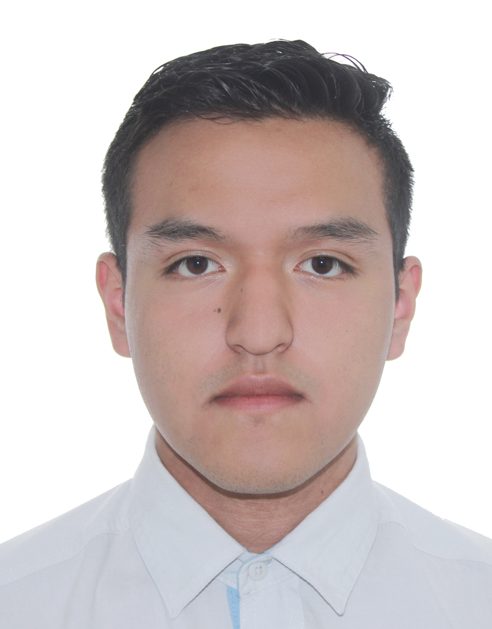

# Carlos Daniel Reséndiz Flores

## **Bio**

I am an undergraduate student pursuing a **Bachelor’s Degree in Technology** at the **National School of Higher Studies (ENES) Juriquilla**, **National Autonomous University of Mexico (UNAM)**.

My research interests lie at the intersection of **Artificial Intelligence, Biomedical Engineering, Applied Mathematics, Physics, and Aerospace Engineering**. I enjoy developing computational methods that integrate machine learning, scientific computing, and mathematical modeling to solve multidisciplinary problems.

Currently, I participate in research projects involving:

- Magnetic Resonance Imaging (MRI)
- Deep Learning for Biomedical Data Analysis
- Mathematical and Computational Modeling
- CanSat Aerospace Systems Design
- Scientific Computing with Python

My long-term goal is to contribute to the development of computational technologies that advance scientific research and address high-impact engineering and biomedical challenges.

## **Education**

**B.Sc. in Technology** **Escuela Nacional de Estudios Superiores (ENES) Unidad Juriquilla** **Universidad Nacional Autónoma de México (UNAM)**

Expected graduation: 2028

## **Research Interests**

- Artificial Intelligence
- Machine Learning
- Deep Learning
- Medical Image Analysis
- Magnetic Resonance Imaging
- Biomedical Signal Processing
- Mathematical Modeling
- Scientific Computing
- Aerospace Engineering
- Computational Physics

## **Current Projects**

### Deep Learning for MRI

Development of deep learning methodologies for biomedical image reconstruction and analysis, with emphasis on magnetic resonance imaging.

### Mathematical Modeling

Application of computational and mathematical techniques to biological and engineering systems.

### CanSat

Design and development of satellite-inspired embedded systems for aerospace applications, including telemetry, sensors, and autonomous operation.

## **Technical Skills**

**Programming**

- Python
- R
- MATLAB (basic)
- Git & GitHub

**Libraries**

- NumPy
- SciPy
- Pandas
- Matplotlib
- PyTorch
- TensorFlow
- Scikit-learn

**Areas**

- Machine Learning
- Deep Learning
- Scientific Computing
- Data Analysis
- Signal Processing
- Medical Imaging

## **Research Goals**

I aspire to pursue graduate studies focused on Artificial Intelligence and Computational Science, developing novel algorithms that bridge engineering, physics, and biology to create technologies with meaningful scientific and societal impact.